# SQLAlchemy :

SQLAlchemy is an open-source Python library that provides an SQL toolkit and an object–relational mapper for database interactions. It allows developers to work with databases using Python objects, enabling efficient and flexible database access.

```python
 %pip install sqlalchemy ipython-sql
```

```python
%pip install PyMySQl
```

# Restart the Kernel¶

```python
import pandas as pd
import numpy as np
import matplotlib.pyplot as plt
import seaborn as sns
from sqlalchemy import URL,create_engine
```

```python
conn_str = URL.create(
    drivername = "mysql+pymysql",
    username = "root",
    password = "root",
    host = "127.0.0.1",
    port = 3306,
    database = "final_project"
)
```

```python
engine = create_engine(conn_str)
```

```python
engine.url
```

```
mysql+pymysql://root:***@127.0.0.1:3306/final_project
```

# Reading data from mysql database¶

```python
conn = engine.connect()
# to view all the tables present in weekday911
df = pd.read_sql("show tables;",conn)
print(df)
```

```
  Tables_in_final_project
0             final_train
```

```python
df = pd.read_sql('select * from final_train',conn)
```

```python
for i in df.columns:
    print(f"{i}")
    print(df[i].unique())
```

[output not shown]

[output cut: 154 more lines]

```
 '279' '192' '304' '330' '150' '207' '436' '78' '54' '89' '143' '105'
 '132' '480' '56' '159' '300' '376' '117' '71' '490' '173' '46' '228'
 '308' '236' '570' '380' '296' '156' '103' '45' '65' '53' '360' '62' '218'
 '178' '239' '405' '148' '190' '149' '153' '162' '230' '86' '234' '246'
 '500' '186' '119' '107' '209' '208' '243' '40' '250' '311' '400' '161'
 '196' '324' '157' '145' '181' '26' '211' '9' '205' '36' '61' '146' '292'
 '142' '350' '496' '253']
Loan_Amount_Term
['360' '120' '240' '' '180' '60' '300' '480' '36' '84' '12']
Credit_History
['1' '0' '']
Property_Area
['Urban' 'Rural' 'Semiurban']
Loan_Status
['Y' 'N']
```

```python
for i in df.columns:
     df[i] = df[i].replace(['NULL', 'nan','','None','N/A','null'], pd.NA)
```

```python
df.info()
```

```
<class 'pandas.core.frame.DataFrame'>
RangeIndex: 614 entries, 0 to 613
Data columns (total 13 columns):
 #   Column             Non-Null Count  Dtype
---  ------             --------------  -----
 0   Loan_ID            614 non-null    object
 1   Gender             601 non-null    object
 2   Married            611 non-null    object
 3   Dependents         599 non-null    object
 4   Education          614 non-null    object
 5   Self_Employed      582 non-null    object
 6   ApplicantIncome    614 non-null    int64
 7   CoapplicantIncome  614 non-null    int64
 8   LoanAmount         592 non-null    object
 9   Loan_Amount_Term   600 non-null    object
 10  Credit_History     564 non-null    object
 11  Property_Area      614 non-null    object
 12  Loan_Status        614 non-null    object
dtypes: int64(2), object(11)
memory usage: 62.5+ KB
```

```python
df.isna().sum()
```

[output not shown]

## Categorical data replace with mode .

## Continous data replace with mean or median

```python
df['Gender'] = df['Gender'].fillna(df['Gender'].mode()[0])
```

```python
df['Gender'].unique()
```

```
array(['Male', 'Female'], dtype=object)
```

```python
df['Married'] = df['Married'].fillna(df['Married'].mode()[0])
```

```python
df['Married'].unique()
```

```
array(['No', 'Yes'], dtype=object)
```

```python
df['Dependents'] = df['Dependents'].replace('3+', '3')
df['Dependents'] = pd.to_numeric(df['Dependents'])
```

```python
df['Dependents'].unique()
```

```
array([0, 1, 2, 3])
```

```python
df['Self_Employed'] = df['Self_Employed'].fillna(df['Self_Employed'].mode()[0])
```

```python
df['Self_Employed'].unique()
```

```
array(['No', 'Yes'], dtype=object)
```

```python
print("LoanAmount Median:", df['LoanAmount'].median())
print("Loan_Amount_Term Mean:", round(df['Loan_Amount_Term'].mean(), 2))
print("Credit_History Mean:", round(df['Credit_History'].mean(), 2))
```

```
LoanAmount Median: 128.0
Loan_Amount_Term Mean: 342.41
Credit_History Mean: 0.86
```

```python
df['LoanAmount'].unique()
```

```
array([128.,  66., 120., 141., 267.,  95., 158., 168., 349.,  70., 109.,
       200., 114.,  17., 125., 100.,  76., 133., 115., 104., 315., 116.,
       112., 151., 191., 122., 110.,  35., 201.,  74., 106., 320., 144.,
       184.,  80.,  47.,  75., 134.,  96.,  88.,  44., 286.,  97., 135.,
       180.,  99., 165., 258., 126., 312., 136., 172.,  81., 187., 113.,
       176., 130., 111., 167., 265.,  50., 210., 175., 131., 188.,  25.,
       137., 160., 225., 216.,  94., 139., 152., 118., 185., 154.,  85.,
       259., 194.,  93., 370., 182., 650., 102., 290.,  84., 242., 129.,
        30., 244., 600., 255.,  98., 275., 121.,  63., 700.,  87., 101.,
       495.,  67.,  73., 260., 108.,  58.,  48., 164., 170.,  83.,  90.,
       166., 124.,  55.,  59., 127., 214., 240.,  72.,  60., 138.,  42.,
       280., 140., 155., 123., 279., 192., 304., 330., 150., 207., 436.,
        78.,  54.,  89., 143., 105., 132., 480.,  56., 159., 300., 376.,
       117.,  71., 490., 173.,  46., 228., 308., 236., 570., 380., 296.,
       156., 103.,  45.,  65.,  53., 360.,  62., 218., 178., 239., 405.,
       148., 190., 149., 153., 162., 230.,  86., 234., 246., 500., 186.,
       119., 107., 209., 208., 243.,  40., 250., 311., 400., 161., 196.,
       324., 157., 145., 181.,  26., 211.,   9., 205.,  36.,  61., 146.,
       292., 142., 350., 496., 253.])
```

```python
df['Loan_Amount_Term'].unique()
```

```
array([360., 120., 240., 180.,  60., 300., 480.,  36.,  84.,  12.])
```

```python
df['Credit_History'].unique()
```

```
array([1., 0.])
```

```python
df.isna().sum()
```

```
Loan_ID              0
Gender               0
Married              0
Dependents           0
Education            0
Self_Employed        0
ApplicantIncome      0
CoapplicantIncome    0
LoanAmount           0
Loan_Amount_Term     0
Credit_History       0
Property_Area        0
Loan_Status          0
dtype: int64
```

```python
df.duplicated().sum()
```

```
np.int64(0)
```

```python
df.info
```

```
<bound method DataFrame.info of       Loan_ID  Gender Married  Dependents     Education Self_Employed  \
0    LP001002    Male      No           0      Graduate            No
1    LP001003    Male     Yes           1      Graduate            No
2    LP001005    Male     Yes           0      Graduate           Yes
3    LP001006    Male     Yes           0  Not Graduate            No
4    LP001008    Male      No           0      Graduate            No
..        ...     ...     ...         ...           ...           ...
609  LP002978  Female      No           0      Graduate            No
610  LP002979    Male     Yes           3      Graduate            No
611  LP002983    Male     Yes           1      Graduate            No
612  LP002984    Male     Yes           2      Graduate            No
613  LP002990  Female      No           0      Graduate           Yes

     ApplicantIncome  CoapplicantIncome  LoanAmount  Loan_Amount_Term  \
0               5849                  0       128.0             360.0
```

[output cut: 25 more lines]

```python
##If the duplicate rows are in the data than drop the duplicates.
df.drop_duplicates()
```

|  | Loan_ID | Gender | Married | Dependents | Education | Self_Employed | ApplicantIncome | CoapplicantIncome | LoanAmount | Loan_Amount_Term | Credit_History | Property_Area | Loan_Status |
| --- | --- | --- | --- | --- | --- | --- | --- | --- | --- | --- | --- | --- | --- |
| 0 | LP001002 | Male | No | 0 | Graduate | No | 5849 | 0 | 128.0 | 360.0 | 1.0 | Urban | Y |
| 1 | LP001003 | Male | Yes | 1 | Graduate | No | 4583 | 1508 | 128.0 | 360.0 | 1.0 | Rural | N |
| 2 | LP001005 | Male | Yes | 0 | Graduate | Yes | 3000 | 0 | 66.0 | 360.0 | 1.0 | Urban | Y |
| 3 | LP001006 | Male | Yes | 0 | Not Graduate | No | 2583 | 2358 | 120.0 | 360.0 | 1.0 | Urban | Y |
| 4 | LP001008 | Male | No | 0 | Graduate | No | 6000 | 0 | 141.0 | 360.0 | 1.0 | Urban | Y |
| ... | ... | ... | ... | ... | ... | ... | ... | ... | ... | ... | ... | ... | ... |
| 609 | LP002978 | Female | No | 0 | Graduate | No | 2900 | 0 | 71.0 | 360.0 | 1.0 | Rural | Y |
| 610 | LP002979 | Male | Yes | 3 | Graduate | No | 4106 | 0 | 40.0 | 180.0 | 1.0 | Rural | Y |
| 611 | LP002983 | Male | Yes | 1 | Graduate | No | 8072 | 240 | 253.0 | 360.0 | 1.0 | Urban | Y |
| 612 | LP002984 | Male | Yes | 2 | Graduate | No | 7583 | 0 | 187.0 | 360.0 | 1.0 | Urban | Y |
| 613 | LP002990 | Female | No | 0 | Graduate | Yes | 4583 | 0 | 133.0 | 360.0 | 0.0 | Semiurban | N |

614 rows × 13 columns

```python
df.duplicated().sum()
```

```
np.int64(0)
```

```python
cat = list(df.columns[df.dtypes=="object"])
con= list(df.columns[df.dtypes!="object"])
```

```python
print(df.columns)
```

```
Index(['Loan_ID', 'Gender', 'Married', 'Dependents', 'Education',
       'Self_Employed', 'ApplicantIncome', 'CoapplicantIncome', 'LoanAmount',
       'Loan_Amount_Term', 'Credit_History', 'Property_Area', 'Loan_Status'],
      dtype='object')
```

```python
print(cat)
```

```
['Loan_ID', 'Gender', 'Married', 'Education', 'Self_Employed', 'Property_Area', 'Loan_Status']
```

```python
print(con)
```

```
['Dependents', 'ApplicantIncome', 'CoapplicantIncome', 'LoanAmount', 'Loan_Amount_Term', 'Credit_History']
```

# Pipeline that handles Data cleaning process

Though in current dataset,we dont have missing data,however,in future we may come across new data that contains missing data

```python
# Import Pipeline
from sklearn.pipeline import make_pipeline
# Import Imputer that performs missing data handling by replacing missing data with central tendency
from sklearn.impute import SimpleImputer
# column Transormer combines pipelines.here we have 2 pipelines-categorical and continuous
from sklearn.compose import ColumnTransformer
```

make_pipeline → lets you chain preprocessing steps.

SimpleImputer → handles missing values (replace with mean, median, or mode).

ColumnTransformer → applies different pipelines to different sets of columns.

```python
# pipeline to handle numerical numerical missing content
num_pipe = make_pipeline(SimpleImputer(strategy="median"))

# pipeline to handle categorical missing content
cat_pipe = make_pipeline(SimpleImputer(strategy="most_frequent"))
```

```python
# combine both the pipeline
final_pipe = ColumnTransformer([
    ('cat',cat_pipe,cat),
    ('con',num_pipe,con)
]).set_output(transform="pandas")
```

ColumnTransformer applies different preprocessing to different sets of columns:

'cat' → applies cat_pipe to categorical columns (cat list).

'con' → applies num_pipe to numerical columns (con list).

```python
final_pipe
```

```
ColumnTransformer(transformers=[('cat',
                                 Pipeline(steps=[('simpleimputer',
                                                  SimpleImputer(strategy='most_frequent'))]),
                                 ['Loan_ID', 'Gender', 'Married', 'Education',
                                  'Self_Employed', 'Property_Area',
                                  'Loan_Status']),
                                ('con',
                                 Pipeline(steps=[('simpleimputer',
                                                  SimpleImputer(strategy='median'))]),
                                 ['Dependents', 'ApplicantIncome',
                                  'CoapplicantIncome', 'LoanAmount',
                                  'Loan_Amount_Term', 'Credit_History'])])
```

```python
df_cleaned = final_pipe.fit_transform(df)
df_cleaned.head(3)
```

|  | cat__Loan_ID | cat__Gender | cat__Married | cat__Education | cat__Self_Employed | cat__Property_Area | cat__Loan_Status | con__Dependents | con__ApplicantIncome | con__CoapplicantIncome | con__LoanAmount | con__Loan_Amount_Term | con__Credit_History |
| --- | --- | --- | --- | --- | --- | --- | --- | --- | --- | --- | --- | --- | --- |
| 0 | LP001002 | Male | No | Graduate | No | Urban | Y | 0.0 | 5849.0 | 0.0 | 128.0 | 360.0 | 1.0 |
| 1 | LP001003 | Male | Yes | Graduate | No | Rural | N | 1.0 | 4583.0 | 1508.0 | 128.0 | 360.0 | 1.0 |
| 2 | LP001005 | Male | Yes | Graduate | Yes | Urban | Y | 0.0 | 3000.0 | 0.0 | 66.0 | 360.0 | 1.0 |

```python
new_cols = []
for i in df_cleaned.columns:
    c = i.split('__')[-1]
    new_cols.append(c)
print(new_cols)
```

```
['Loan_ID', 'Gender', 'Married', 'Education', 'Self_Employed', 'Property_Area', 'Loan_Status', 'Dependents', 'ApplicantIncome', 'CoapplicantIncome', 'LoanAmount', 'Loan_Amount_Term', 'Credit_History']
```

```python
df_cleaned.columns
```

```
Index(['cat__Loan_ID', 'cat__Gender', 'cat__Married', 'cat__Education',
       'cat__Self_Employed', 'cat__Property_Area', 'cat__Loan_Status',
       'con__Dependents', 'con__ApplicantIncome', 'con__CoapplicantIncome',
       'con__LoanAmount', 'con__Loan_Amount_Term', 'con__Credit_History'],
      dtype='object')
```

```python
df_cleaned.columns = new_cols
df_cleaned.columns
```

```
Index(['Loan_ID', 'Gender', 'Married', 'Education', 'Self_Employed',
       'Property_Area', 'Loan_Status', 'Dependents', 'ApplicantIncome',
       'CoapplicantIncome', 'LoanAmount', 'Loan_Amount_Term',
       'Credit_History'],
      dtype='object')
```

```python
df_cleaned.head()
```

|  | Loan_ID | Gender | Married | Education | Self_Employed | Property_Area | Loan_Status | Dependents | ApplicantIncome | CoapplicantIncome | LoanAmount | Loan_Amount_Term | Credit_History |
| --- | --- | --- | --- | --- | --- | --- | --- | --- | --- | --- | --- | --- | --- |
| 0 | LP001002 | Male | No | Graduate | No | Urban | Y | 0.0 | 5849.0 | 0.0 | 128.0 | 360.0 | 1.0 |
| 1 | LP001003 | Male | Yes | Graduate | No | Rural | N | 1.0 | 4583.0 | 1508.0 | 128.0 | 360.0 | 1.0 |
| 2 | LP001005 | Male | Yes | Graduate | Yes | Urban | Y | 0.0 | 3000.0 | 0.0 | 66.0 | 360.0 | 1.0 |
| 3 | LP001006 | Male | Yes | Not Graduate | No | Urban | Y | 0.0 | 2583.0 | 2358.0 | 120.0 | 360.0 | 1.0 |
| 4 | LP001008 | Male | No | Graduate | No | Urban | Y | 0.0 | 6000.0 | 0.0 | 141.0 | 360.0 | 1.0 |

```python
df_cleaned.to_csv('Cleaned Dataset.csv')
# to changes in main file
```

```python
df_cleaned.to_csv('final Dataset4.csv',index=False)
```

# Statistical Analysis¶

```python
df[con].describe().T
```

|  | count | mean | std | min | 25% | 50% | 75% | max |
| --- | --- | --- | --- | --- | --- | --- | --- | --- |
| Dependents | 614.0 | 0.744300 | 1.009623 | 0.0 | 0.00 | 0.0 | 1.00 | 3.0 |
| ApplicantIncome | 614.0 | 5403.459283 | 6109.041673 | 150.0 | 2877.50 | 3812.5 | 5795.00 | 81000.0 |
| CoapplicantIncome | 614.0 | 1621.245928 | 2926.248406 | 0.0 | 0.00 | 1188.5 | 2297.25 | 41667.0 |
| LoanAmount | 614.0 | 145.752443 | 84.107233 | 9.0 | 100.25 | 128.0 | 164.75 | 700.0 |
| Loan_Amount_Term | 614.0 | 342.410423 | 64.428629 | 12.0 | 360.00 | 360.0 | 360.00 | 480.0 |
| Credit_History | 614.0 | 0.855049 | 0.352339 | 0.0 | 1.00 | 1.0 | 1.00 | 1.0 |

Shows statistics (mean, median, std dev, min, max) for numerical features.

Example: Average LoanAmount ≈ 146, mean ApplicantIncome ≈ 5400.

```python
df[cat].describe().T
```

|  | count | unique | top | freq |
| --- | --- | --- | --- | --- |
| Loan_ID | 614 | 614 | LP002990 | 1 |
| Gender | 614 | 2 | Male | 502 |
| Married | 614 | 2 | Yes | 401 |
| Education | 614 | 2 | Graduate | 480 |
| Self_Employed | 614 | 2 | No | 532 |
| Property_Area | 614 | 3 | Semiurban | 233 |
| Loan_Status | 614 | 2 | Y | 422 |

# Univariate Analysis

Continuous → Histograms, Boxplots

Categorical → Countplots

```python
print(cat)
```

```
['Loan_ID', 'Gender', 'Married', 'Education', 'Self_Employed', 'Property_Area', 'Loan_Status']
```

```python
df_cleaned['LoanAmount'].value_counts()
```

```
LoanAmount
128.0    33
120.0    20
110.0    17
100.0    15
160.0    12
         ..
292.0     1
142.0     1
350.0     1
496.0     1
253.0     1
Name: count, Length: 203, dtype: int64
```

```python
import matplotlib.pyplot as plt
import seaborn as sns
```

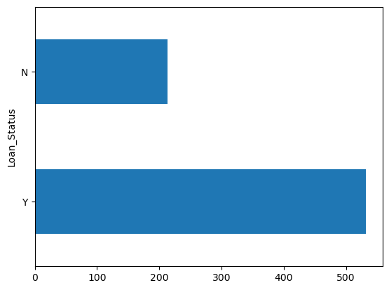

```python
for i in cat:
    df_cleaned[i].value_counts().plot(kind="barh")
```

[figure not shown]

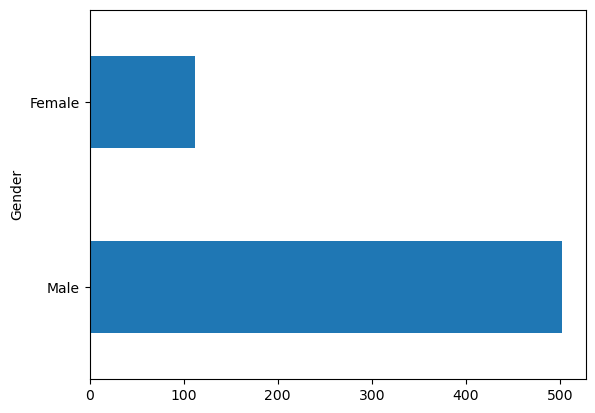

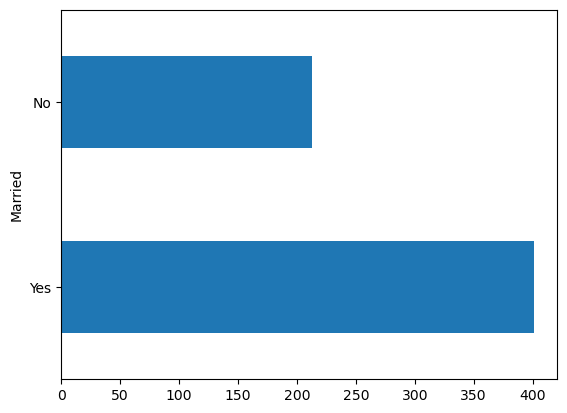

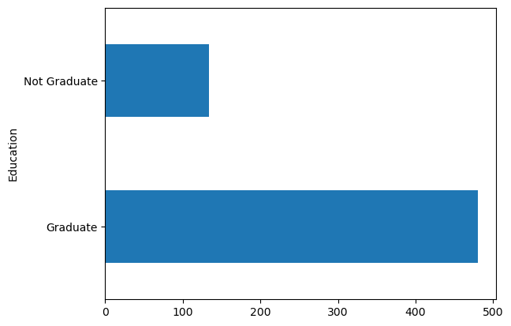

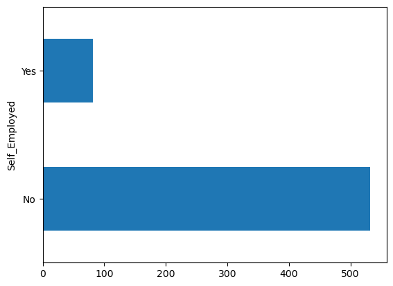

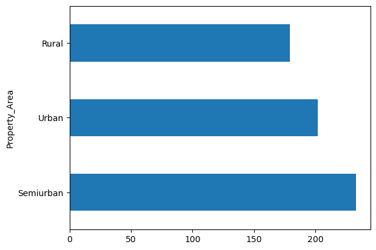

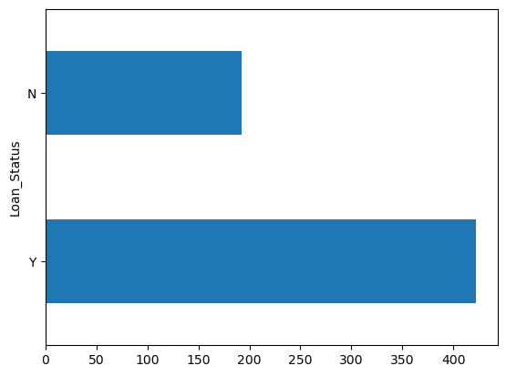

```python
for i in cat:
    df_cleaned[i].value_counts().plot(kind="barh")
    plt.show()
```

[figure not shown]

```python
import seaborn as sns
sns.countplot(df_cleaned['LoanAmount'])
```

[output not shown]

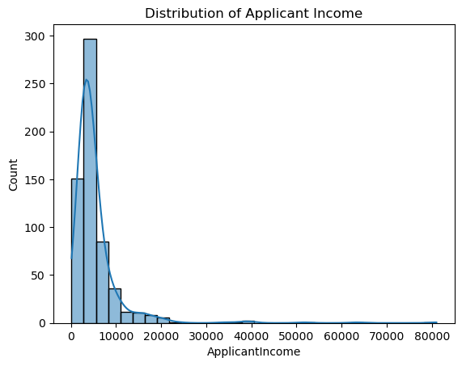

```python
# Histogram for ApplicantIncome
sns.histplot(df['ApplicantIncome'], bins=30, kde=True)
plt.title("Distribution of Applicant Income")
plt.show()
```

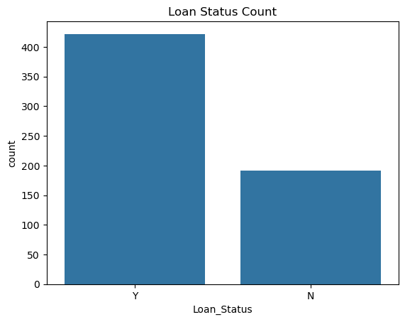

```python
# Countplot for Loan_Status
sns.countplot(x='Loan_Status', data=df)
plt.title("Loan Status Count")
plt.show()
```

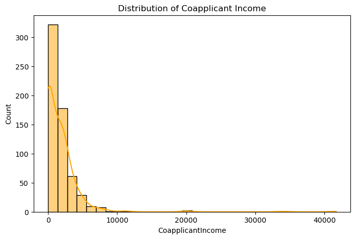

```python
# Coapplicant Income
plt.figure(figsize=(8,5))
sns.histplot(df['CoapplicantIncome'], bins=30, kde=True, color="orange")
plt.title("Distribution of Coapplicant Income")
plt.show()
```

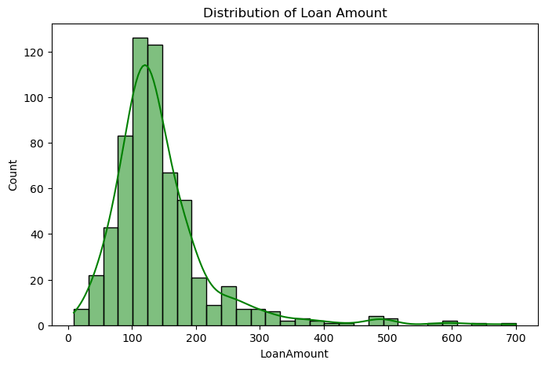

```python
# Loan Amount
plt.figure(figsize=(8,5))
sns.histplot(df['LoanAmount'], bins=30, kde=True, color="green")
plt.title("Distribution of Loan Amount")
plt.show()
```

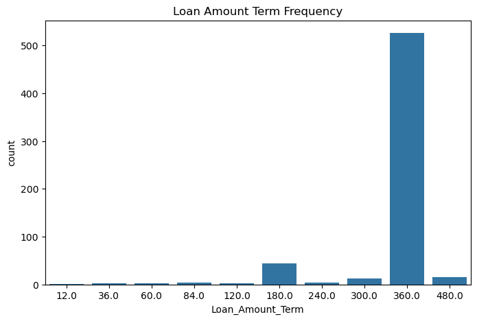

```python
# Loan Amount Term
plt.figure(figsize=(8,5))
sns.countplot(x='Loan_Amount_Term', data=df)
plt.title("Loan Amount Term Frequency")
plt.show()
```

# Categorical Variables¶

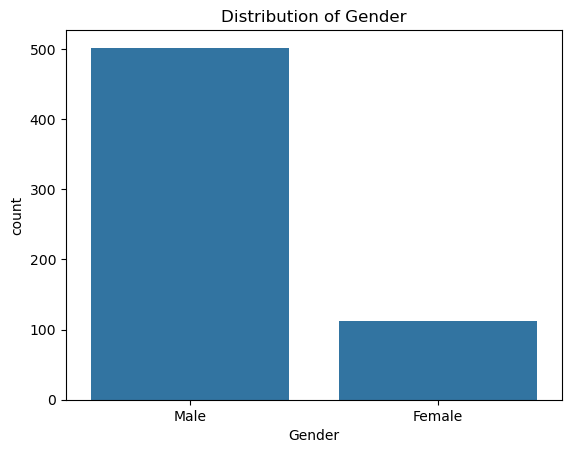

```python
# Gender
sns.countplot(x='Gender', data=df)
plt.title("Distribution of Gender")
plt.show()
```

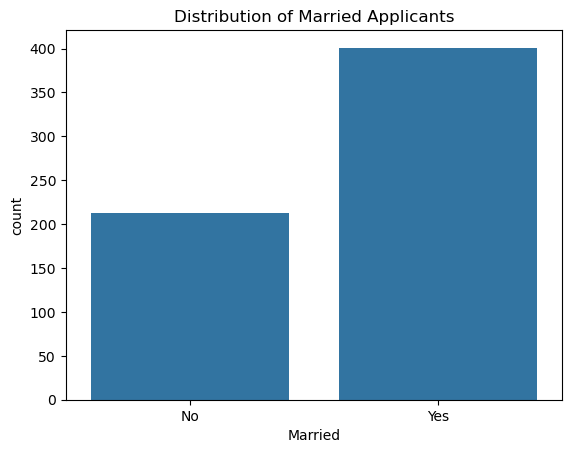

```python
# Married
sns.countplot(x='Married', data=df)
plt.title("Distribution of Married Applicants")
plt.show()
```

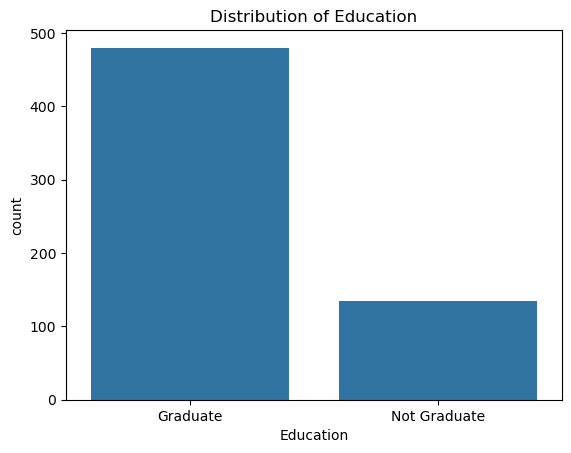

```python
# Education
sns.countplot(x='Education', data=df)
plt.title("Distribution of Education")
plt.show()
```

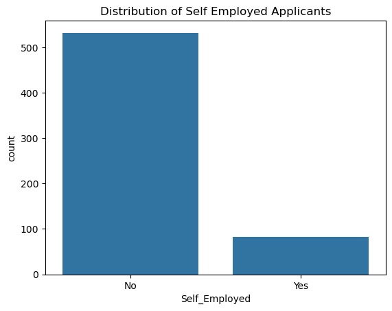

```python
# Self Employed
sns.countplot(x='Self_Employed', data=df)
plt.title("Distribution of Self Employed Applicants")
plt.show()
```

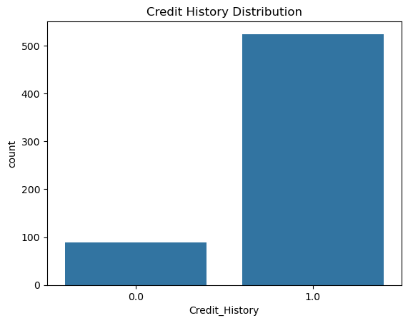

```python
# Credit History
sns.countplot(x='Credit_History', data=df)
plt.title("Credit History Distribution")
plt.show()
```

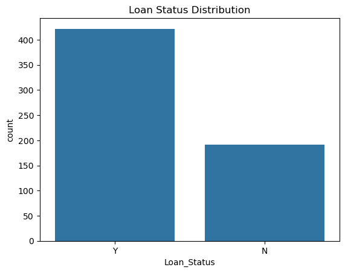

```python
# Loan Status
sns.countplot(x='Loan_Status', data=df)
plt.title("Loan Status Distribution")
plt.show()
```

# 1. Continuous vs Continuous

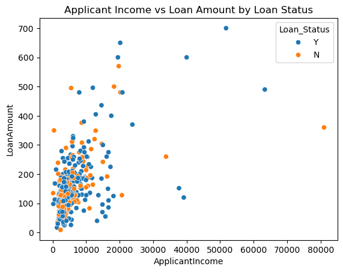

```python
# Scatter Plot
sns.scatterplot(x='ApplicantIncome', y='LoanAmount', hue='Loan_Status', data=df)
plt.title("Applicant Income vs Loan Amount by Loan Status")
plt.show()
```

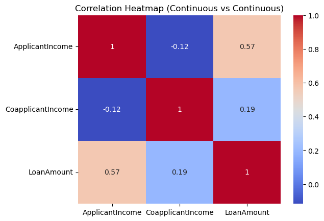

```python
# Convert numeric columns from string → numeric
df['ApplicantIncome'] = pd.to_numeric(df['ApplicantIncome'], errors='coerce')
df['CoapplicantIncome'] = pd.to_numeric(df['CoapplicantIncome'], errors='coerce')
df['LoanAmount'] = pd.to_numeric(df['LoanAmount'], errors='coerce')

# Now correlation heatmap
sns.heatmap(df[['ApplicantIncome','CoapplicantIncome','LoanAmount']].corr(),
            annot=True, cmap="coolwarm")
plt.title("Correlation Heatmap (Continuous vs Continuous)")
plt.show()
```

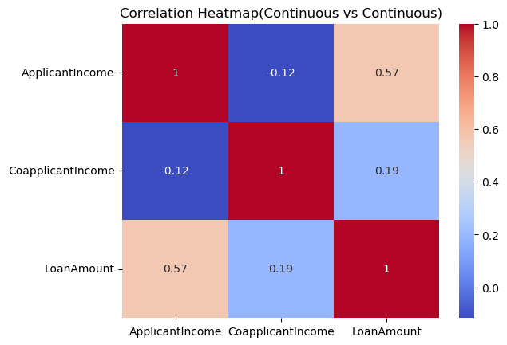

```python
# Correlation Heatmap
sns.heatmap(df[['ApplicantIncome','CoapplicantIncome','LoanAmount']].corr(),annot=True,cmap="coolwarm")
plt.title("Correlation Heatmap(Continuous vs Continuous)")
plt.show()
```

```python
df[['ApplicantIncome','CoapplicantIncome','LoanAmount']].dtypes
```

```
ApplicantIncome        int64
CoapplicantIncome      int64
LoanAmount           float64
dtype: object
```

# Categorical vs Categorical (Loan_Status)

```
Loan_Status    N    Y
Gender
Female        37   75
Male         155  347
```

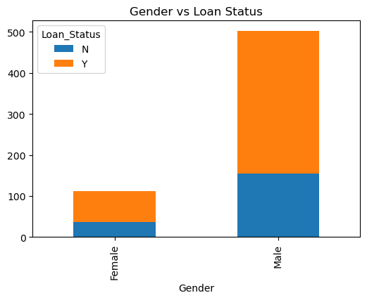

```python
# Crosstab
print(pd.crosstab(df['Gender'], df['Loan_Status']))

# Stacked Bar Plot
pd.crosstab(df['Gender'], df['Loan_Status']).plot(kind="bar", stacked=True, figsize=(6,4))
plt.title("Gender vs Loan Status")
plt.show()
```

Some very high incomes (outliers), but not always approved → means income alone is not enough.

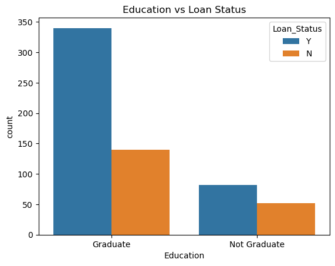

```python
# Education vs Loan_Status
sns.countplot(x="Education", hue="Loan_Status", data=df)
plt.title("Education vs Loan Status")
plt.show()
```

# Categorical vs Continuous

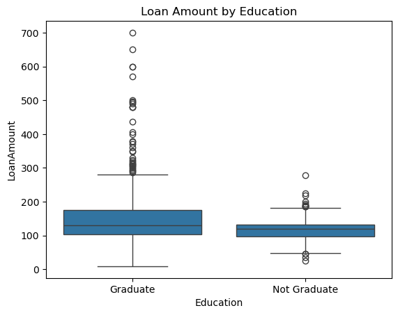

```python
# Boxplot
sns.boxplot(x="Education", y="LoanAmount", data=df)
plt.title("Loan Amount by Education")
plt.show()
```

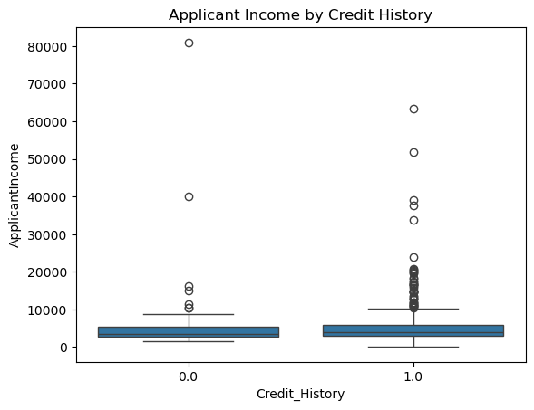

```python
# Credit History vs ApplicantIncome
sns.boxplot(x="Credit_History", y="ApplicantIncome", data=df)
plt.title("Applicant Income by Credit History")
plt.show()
```

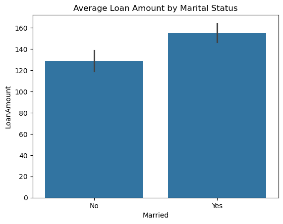

```python
# Barplot (mean values)
sns.barplot(x="Married", y="LoanAmount", data=df)
plt.title("Average Loan Amount by Marital Status")
plt.show()
```

# Multivariate Analysis - Continuous Data¶

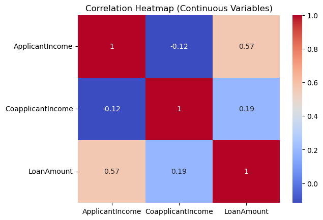

```python
sns.heatmap(df[['ApplicantIncome','CoapplicantIncome','LoanAmount']].corr(),
            annot=True, cmap="coolwarm")
plt.title("Correlation Heatmap (Continuous Variables)")
plt.show()
```

Heatmap shows correlation between continuous variables.

Suggests other factors (like Credit_History) matter more.

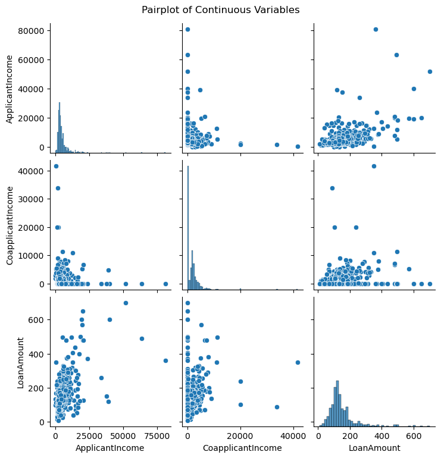

```python
sns.pairplot(df[['ApplicantIncome','CoapplicantIncome','LoanAmount']])
plt.suptitle("Pairplot of Continuous Variables", y=1.02)
plt.show()
```

## Summary of Insights & Recommendations

### Recommendations

- *Credit History as Key Feature:* Banks should continue to rely on credit history as a primary factor in loan approval.
- *Outlier Handling:* Apply capping or transformation for ApplicantIncome and LoanAmount to reduce skewness for modeling.
- *Additional Data:* Collect more variables (employment stability, existing debts) to improve prediction power.
- *Applicant Support:* Applicants without credit history could be encouraged to build credit (e.g., through smaller loans or credit cards).
- *Balanced Loan Policies:* While income is important, banks should avoid rejecting applications solely on income, as credit history is more reliable for default prediction.